# R Notebook

# Introduction

## Project Overview

The research objectives focus on two primary goals. First, the aim is to develop accurate predictive models for estimating credit scores based on the available data. Second, key indicators are identified to explain why certain individuals receive a particular credit score and what actions can be taken to achieve a better rating. Understanding these underlying factors provides valuable insights for financial institutions, policymakers, and individuals seeking to maintain or improve their creditworthiness.

To address these research questions, a comparative analysis of multiple modeling techniques is conducted:

1. Multinomial Logistic Regression
2. Ordinal Logistic Regression
3. Decision Tree
4. Random Forest

Each of these models offers distinct strengths and approaches for handling complex datasets and predicting outcomes. To identify the best-performing model, various metrics such as Accuracy, Recall, Precision, and F1 Scores are compared.

Overall, this study highlights the effectiveness of data-driven methods in understanding financial behavior and credit risk.

## Import Dataset

```r
data <- read.csv("C:/Users/mihim/Desktop/Uni/R/Project/data/train.csv", header = TRUE, sep = ",")
```

**Objective**

Create a machine learning model to classify a person into “Good”, “Standard” or “Poor” credit score categories based on credit-related information.

**Dataset used:**

- “Credit score classification” by Rohan Paris
- https://www.kaggle.com/datasets/parisrohan/credit-score-classification
- License: “CC0: Public Domain”

**Dataset Information**

- train.csv
  - 100000 observations
  - 12500 people
  - 8 observations per person (different months)

We will use the train.csv file and do a 80/20 train test split.

**The variables:**

- ID: Unique identifier for each entry in the dataset.
- Customer_ID: Identifier for each customer.
- Month: Month of data collection.
- Name: Name of the customer.
- Age: Age of the customer.
- SSN: Social Security Number of the customer.
- Occupation: Occupation of the customer.
- Annual_Income: Annual income of the customer.
- Monthly_Inhand_Salary: Monthly salary after deductions.
- Num_Bank_Accounts: Number of bank accounts the customer has.
- Num_Credit_Card: Number of credit cards the customer has.
- Interest_Rate: Interest rate applied on loans.
- Num_of_Loan: Number of loans the customer has.
- Type_of_Loan: Type of loan taken by the customer.
- Delay_from_due_date: Number of days delayed from due date for payments.
- Num_of_Delayed_Payment: Number of delayed payments made by the customer.
- Changed_Credit_Limit: Indicates if the credit limit has been changed.
- Num_Credit_Inquiries: Number of credit inquiries made by the customer.
- Credit_Mix: Mix of different types of credit accounts held by the customer.
- Outstanding_Debt: Amount of outstanding debt.
- Credit_Utilization_Ratio: Ratio of credit used to credit available.
- Credit_History_Age: Age of credit history.
- Payment_of_Min_Amount: Indicates if minimum payment amount is met.
- Total_EMI_per_month: Total Equated Monthly Installment (EMI) paid by the customer.
- Amount_invested_monthly: Amount invested monthly by the customer.
- Payment_Behaviour: Payment behavior of the customer.
- Monthly_Balance: Monthly balance in the account.
- Credit_Score: Target variable - credit score of the customer.

```r
head(data)
```

|  | ID | Customer_ID | Month | Name | Age | SSN | Occupation | Annual_Income | Monthly_Inhand_Salary | Num_Bank_Accounts | Num_Credit_Card | Interest_Rate | Num_of_Loan | Type_of_Loan | Delay_from_due_date | Num_of_Delayed_Payment | Changed_Credit_Limit | Num_Credit_Inquiries | Credit_Mix | Outstanding_Debt | Credit_Utilization_Ratio | Credit_History_Age | Payment_of_Min_Amount | Total_EMI_per_month | Amount_invested_monthly | Payment_Behaviour | Monthly_Balance | Credit_Score |
| --- | --- | --- | --- | --- | --- | --- | --- | --- | --- | --- | --- | --- | --- | --- | --- | --- | --- | --- | --- | --- | --- | --- | --- | --- | --- | --- | --- | --- |
| 1 | 5634 | CUS_0xd40 | January | Aaron Maashoh | 23 | 821-00-0265 | Scientist | 19114.12 | 1824.843 | 3 | 4 | 3 | 4 | Auto Loan, Credit-Builder Loan, Personal Loan, and Home Equity Loan | 3 | 7 | 11.27 | 4 | _ | 809.98 | 26.82262 | 22 Years and 1 Months | No | 49.57495 | 80.41529543900253 | High_spent_Small_value_payments | 312.49408867943663 | Good |
| 2 | 5635 | CUS_0xd40 | February | Aaron Maashoh | 23 | 821-00-0265 | Scientist | 19114.12 | NA | 3 | 4 | 3 | 4 | Auto Loan, Credit-Builder Loan, Personal Loan, and Home Equity Loan | -1 |  | 11.27 | 4 | Good | 809.98 | 31.94496 | NA | No | 49.57495 | 118.28022162236736 | Low_spent_Large_value_payments | 284.62916249607184 | Good |
| 3 | 5636 | CUS_0xd40 | March | Aaron Maashoh | -500 | 821-00-0265 | Scientist | 19114.12 | NA | 3 | 4 | 3 | 4 | Auto Loan, Credit-Builder Loan, Personal Loan, and Home Equity Loan | 3 | 7 | _ | 4 | Good | 809.98 | 28.60935 | 22 Years and 3 Months | No | 49.57495 | 81.699521264648 | Low_spent_Medium_value_payments | 331.2098628537912 | Good |
| 4 | 5637 | CUS_0xd40 | April | Aaron Maashoh | 23 | 821-00-0265 | Scientist | 19114.12 | NA | 3 | 4 | 3 | 4 | Auto Loan, Credit-Builder Loan, Personal Loan, and Home Equity Loan | 5 | 4 | 6.27 | 4 | Good | 809.98 | 31.37786 | 22 Years and 4 Months | No | 49.57495 | 199.4580743910713 | Low_spent_Small_value_payments | 223.45130972736786 | Good |
| 5 | 5638 | CUS_0xd40 | May | Aaron Maashoh | 23 | 821-00-0265 | Scientist | 19114.12 | 1824.843 | 3 | 4 | 3 | 4 | Auto Loan, Credit-Builder Loan, Personal Loan, and Home Equity Loan | 6 |  | 11.27 | 4 | Good | 809.98 | 24.79735 | 22 Years and 5 Months | No | 49.57495 | 41.420153086217326 | High_spent_Medium_value_payments | 341.48923103222177 | Good |
| 6 | 5639 | CUS_0xd40 | June | Aaron Maashoh | 23 | 821-00-0265 | Scientist | 19114.12 | NA | 3 | 4 | 3 | 4 | Auto Loan, Credit-Builder Loan, Personal Loan, and Home Equity Loan | 8 | 4 | 9.27 | 4 | Good | 809.98 | 27.26226 | 22 Years and 6 Months | No | 49.57495 | 62.430172331195294 | !@9#%8 | 340.4792117872438 | Good |

```r
colnames(data)
```

```
##  [1] "ID"                       "Customer_ID"
##  [3] "Month"                    "Name"
##  [5] "Age"                      "SSN"
##  [7] "Occupation"               "Annual_Income"
##  [9] "Monthly_Inhand_Salary"    "Num_Bank_Accounts"
## [11] "Num_Credit_Card"          "Interest_Rate"
## [13] "Num_of_Loan"              "Type_of_Loan"
## [15] "Delay_from_due_date"      "Num_of_Delayed_Payment"
## [17] "Changed_Credit_Limit"     "Num_Credit_Inquiries"
## [19] "Credit_Mix"               "Outstanding_Debt"
## [21] "Credit_Utilization_Ratio" "Credit_History_Age"
## [23] "Payment_of_Min_Amount"    "Total_EMI_per_month"
## [25] "Amount_invested_monthly"  "Payment_Behaviour"
## [27] "Monthly_Balance"          "Credit_Score"
```

# Data Cleaning

## Removing Columns

We drop columns that are unnecessary or not useful for the model building:

- ID
- Month
- Name
- SSN
- Monthly_Inhand_Salary
- Type_of_Loan

```r
credit_data <- data[, c("Customer_ID","Age", "Occupation", "Annual_Income", "Num_Bank_Accounts", "Interest_Rate", "Num_of_Loan", "Delay_from_due_date", "Num_of_Delayed_Payment", "Changed_Credit_Limit", "Num_Credit_Inquiries", "Credit_Mix", "Outstanding_Debt", "Credit_Utilization_Ratio", "Credit_History_Age", "Payment_of_Min_Amount", "Total_EMI_per_month", "Amount_invested_monthly", "Payment_Behaviour", "Monthly_Balance", "Credit_Score")]

df <- as.data.frame(credit_data)

colSums(is.na(credit_data))
```

```
##              Customer_ID                      Age               Occupation
##                        0                        0                        0
##            Annual_Income        Num_Bank_Accounts            Interest_Rate
##                        0                        0                        0
##              Num_of_Loan      Delay_from_due_date   Num_of_Delayed_Payment
##                        0                        0                        0
##     Changed_Credit_Limit     Num_Credit_Inquiries               Credit_Mix
##                        0                     1965                        0
##         Outstanding_Debt Credit_Utilization_Ratio       Credit_History_Age
##                        0                        0                     9030
##    Payment_of_Min_Amount      Total_EMI_per_month  Amount_invested_monthly
##                        0                        0                        0
##        Payment_Behaviour          Monthly_Balance             Credit_Score
##                        0                        0                        0
```

```r
nrow(df[duplicated(df), ])
```

```
## [1] 0
```

## Encodings for NA values

A table to display the 3 most frequent values for each column is helpful to find some encodings for NA values in the dataset.

```r
# Function to find the 3 most common values
get_top_n_values <- function(column, n = 3) {
  freq_table <- sort(table(column), decreasing = TRUE)
  top_n <- names(freq_table)[1:min(n, length(freq_table))]
  top_n <- c(top_n, rep(NA, n - length(top_n)))
  return(top_n)
}

# Apply function to each column
top_3_values <- lapply(df, get_top_n_values)

# Create a data frame from these results
result_table <- do.call(rbind, lapply(names(top_3_values), function(col) {
  data.frame(
    Column = col,
    Top1 = top_3_values[[col]][1],
    Top2 = top_3_values[[col]][2],
    Top3 = top_3_values[[col]][3]
  )
}))

print(result_table)
```

```
##                      Column                           Top1
## 1               Customer_ID                     CUS_0x1000
## 2                       Age                             38
## 3                Occupation                        _______
## 4             Annual_Income                       17273.83
## 5         Num_Bank_Accounts                              6
## 6             Interest_Rate                              8
## 7               Num_of_Loan                              3
## 8       Delay_from_due_date                             15
## 9    Num_of_Delayed_Payment
## 10     Changed_Credit_Limit                              _
## 11     Num_Credit_Inquiries                              4
## 12               Credit_Mix                       Standard
## 13         Outstanding_Debt                        1360.45
## 14 Credit_Utilization_Ratio                             20
```

[output cut: 29 more lines]

We found 6 encodings for NA values from this table:

- “” (Empty Strings)
- “-”
- “_______”
- “10000”
- “-333333333333333333333333333”
- “NM”

Another one was detected from manual inspection:

- “!@9#%8”

**These encodings are turned into the universal encoding NA.**

```r
df[df == ""] <- NA
df[df == "_"] <- NA
df[df == "!@9#%8"] <- NA
df[df == "NM"] <- NA
df[df == "_______"] <- NA
df[df == "__10000__"] <- NA
df[df == "__-333333333333333333333333333__"] <- NA

colSums(is.na(df))
```

```
##              Customer_ID                      Age               Occupation
##                        0                        0                     7062
##            Annual_Income        Num_Bank_Accounts            Interest_Rate
##                        0                        0                        0
##              Num_of_Loan      Delay_from_due_date   Num_of_Delayed_Payment
##                        0                        0                     7002
##     Changed_Credit_Limit     Num_Credit_Inquiries               Credit_Mix
##                     2091                     1965                    20195
##         Outstanding_Debt Credit_Utilization_Ratio       Credit_History_Age
##                        0                        0                     9030
##    Payment_of_Min_Amount      Total_EMI_per_month  Amount_invested_monthly
##                    12007                        0                     8784
##        Payment_Behaviour          Monthly_Balance             Credit_Score
##                     7600                     1209                        0
```

## Data Cleaning and Outlier Detection

### Functions

Before we start, it is helpful to create some functions which can be used in the cleaning and detection process.

**Load Libraries**

```r
library(dplyr)
```

```r
library(ggplot2)
library(patchwork)
library(knitr)
library(tibble)
```

#### sort_mostcommon

This function processes a column in the dataset to count the occurrences of each unique value and sorts them in descending order by their counts. Here’s the breakdown:

1. Count occurrences: The `count()` function groups the data by the specified column and counts how often each unique value appears.
2. Sort results: The `arrange()` function orders the results by the count (`n`) in descending order, and alphabetically (or naturally) by the column values in case of ties.
3. Print output:
   - If the output format is LaTeX or HTML (e.g., for reports), only the first 10 rows are displayed using `head()`.
   - Otherwise, the full result is printed.

```r
sort_mostcommon <- function(data, column_name) {

  # Sort by count
  result <- data %>%
      count(!!sym(column_name)) %>%
      arrange(desc(n), !!sym(column_name))

  # Display table either full or first 10 for knitting
  if (is_latex_output() || is_html_output()) {
    print(head(result, 10))
  } else {
    print(result)
  }
}
```

#### sort_nonnumeric

This function, processes a column in the dataset to filter out non-numeric values, counts occurrences of each unique non-numeric value, and then sorts these counts in descending order.

1. Extract the column: The specified column is selected from the dataset.
2. Filter non-numeric values: It checks if values in the column are non-numeric. The `filter()` function retains only the non-numeric rows.
3. Count occurrences: The `count()` function groups the non-numeric values and counts their occurrences.
4. Sort results: The `arrange()` function orders the results by count in descending order, and by the column values for ties.
5. Print output:
   - If the output format is LaTeX or HTML (e.g., for reports), only the first 10 rows are shown using `head()`.
   - Otherwise, the entire result is printed.

```r
sort_nonnumeric <- function(data, column_name) {

  column <- data[[column_name]]

  # Filter Non Numeric Values and Sort by Count
  result <- data %>%
    filter(is.na(suppressWarnings(as.numeric(as.character(column))))) %>%
    count(!!sym(column_name)) %>%
    arrange(desc(n), !!sym(column_name))

  # Display table either full or first 10 for knitting
  if (is_latex_output() || is_html_output()) {
    print(head(result, 10))
  } else {
    print(result)
  }
}
```

#### find_outliers

This function identifies outliers in a numeric column based on the interquartile range (IQR) method and visualizes the results using histograms. This is then used to appropriately set the multipliers and filter out the outliers in following steps. In the find_outliers and in the remove_outliers function remove_negatives can be specified. This is used, when negative values make no sense.

1. Input Validation: The column’s values are extracted. If the column is not numeric, the function stops with an error.
2. Remove `NA` values: Missing values (`NA`) are excluded before proceeding.
3. Calculate IQR: The first (`Q1`) and third quartiles (`Q3`) are computed. The IQR is derived as `Q3 - Q1`.
4. Determine Outlier Bounds:
   - The lower bound is `Q1 - multiplier × IQR` (or `0` if `remove_negatives` is `TRUE`).
   - The upper bound is `Q3 + multiplier × IQR`.
5. Identify Outliers: Values outside the bounds are identified as outliers. A table of unique outliers and their counts is created, sorted by value.
6. Display Outlier Table:
   - If the output is LaTeX or HTML, only the first 10 rows are displayed.
   - Otherwise, the full table is printed.
7. Plot Histograms:
   - Histograms are created for:
     - Values below the lower bound.
     - Values within bounds.
     - Values above the upper bound.
   - Because the scales on the y-achsis (counts) differ so much, we opted to using 3 different histograms.
   - Red dashed lines indicate the bounds, with annotations for the lower and upper limits.
8. Combine Plots:
   - All histograms are displayed side by side. For a compact overview.

```r
find_outliers <- function(data, column_name, multiplier = 1.5, remove_negatives = TRUE){

  x <- data[[column_name]]

  if (!is.numeric(x)) {
    stop("Input must be numeric")
  }

  x <- x[!is.na(x)]

  # Calculate IQR
  Q1<-quantile(x,0.25, na.rm = TRUE)
  Q3<-quantile(x,0.75, na.rm = TRUE)
  IQR <- Q3 - Q1

  # Calculate Upper and Lower Bound
  if (remove_negatives) {
    lower <- 0
  } else {
    lower <- Q1 - multiplier * IQR
  }
  upper <- Q3 + multiplier * IQR


  # Create Outliers Table
  outliers <- x[x < lower | x > upper]
  outliers_table <- data.frame(Outliers = outliers) %>%
    count(Outliers) %>%
    arrange(Outliers) # Sort by value (ascending order)

  # Display table either full or first 10 for knitting
  if (is_latex_output() || is_html_output()) {
    print(head(outliers_table, 10))
  } else {
    print(outliers_table)
  }

  plots <- list()

  # Below lower bound Plot
  if (any(x < lower)) {
    below_lower <- x[x < lower]
    plot_below <- ggplot(data.frame(Value = below_lower), aes(x = Value)) +
      geom_histogram(
        breaks = seq(min(below_lower), lower, length.out = nclass.Sturges(below_lower) + 1),
        fill = "skyblue",
        color = "black"
      ) +
      geom_vline(xintercept = lower, color = "red", linetype = "dashed", linewidth = 1.1) +
      annotate("text", x = lower, y = 0,
               label = "Lower Bound", color = "red", vjust = -1, hjust = 1.1) +
      labs(
        title = "Lower Bound",
        x = "Value",
        y = "Frequency",
        subtitle = paste(
          "Values:", length(below_lower),"| Lower:", lower)
      ) +
      theme_minimal()

    plots[[length(plots) + 1]] <- plot_below
  }

  # Within Bounds Plot
  within_bounds <- x[x >= lower & x <= upper]
  if (length(within_bounds) > 0) {
    plot_within <- ggplot(data.frame(Value = within_bounds), aes(x = Value)) +
      geom_histogram(
        bins = nclass.Sturges(within_bounds),
        fill = "skyblue",
        color = "black"
      ) +
      geom_vline(xintercept = lower, color = "red", linetype = "dashed", linewidth = 0.5) +
      geom_vline(xintercept = upper, color = "red", linetype = "dashed", linewidth = 0.5) +
      labs(
        title = "Within Bounds",
        x = "Value",
        y = "Frequency",
        subtitle = paste(
          "Values:", length(within_bounds)
        )
      ) +
      theme_minimal()

    plots[[length(plots) + 1]] <- plot_within
  }

  # Above Upper Bound Plot
  if (any(x > upper)) {
    above_upper <- x[x > upper]
    plot_above <- ggplot(data.frame(Value = above_upper), aes(x = Value)) +
      geom_histogram(
        breaks = seq(upper, max(above_upper), length.out = nclass.Sturges(above_upper) + 1),
        fill = "skyblue",
        color = "black"
      ) +
      geom_vline(xintercept = upper, color = "red", linetype = "dashed", linewidth = 1.1) +
      annotate("text", x = upper, y = 0,
               label = "Upper Bound", color = "red", vjust = -1, hjust = -0.1) +
      labs(
        title = "Upper Bound",
        x = "Value",
        y = "Frequency",
        subtitle = paste(
          "Values:", length(above_upper),"| Upper:", upper)
      ) +
      theme_minimal()

    plots[[length(plots) + 1]] <- plot_above
  }

  # Display Plots next to each other
  plots <- Filter(Negate(is.null), plots)
  plot_number <- length(plots)
  combined_plot <- wrap_plots(plots, ncol = plot_number) +
    theme(plot.margin = margin(10, 10, 10, 10))
  print(combined_plot)
}
```

#### remove_outliers

This function replaces outliers in a numeric column of a dataset with `NA`, based on the interquartile range (IQR) method. The parameters identified during the find_outliers phase through trial and error can be used.

1. Input Validation: The specified column is extracted from the dataset. If the column is not numeric, the function halts with an error.
2. Calculate IQR: Computes the first (`Q1`) and third quartiles (`Q3`) using the `quantile()` function. The IQR is calculated as `Q3 - Q1`.
3. Define Outlier Bounds:
   - The lower bound is:
     - `Q1 - multiplier × IQR` (if `remove_negatives` is `FALSE`).
     - `0` (if `remove_negatives` is `TRUE` to avoid negative bounds).
   - The upper bound is `Q3 + multiplier × IQR`.
4. Identify Outliers: Identifies values outside the lower and upper bounds as outliers.
5. Print Process Details: Displays the lower and upper bounds and the number of outliers removed.
6. Replace Outliers with `NA`: Outlier values are replaced with `NA` in the column.
7. Return Updated Column: The function returns the modified column with outliers replaced by `NA`.

```r
remove_outliers <- function(data, column_name, multiplier = 1.5, remove_negatives = TRUE){

  x <- data[[column_name]]

  if (!is.numeric(x)) {
    stop("Input must be numeric")
  }

  # Calculate IQR
  Q1<-quantile(x,0.25, na.rm = TRUE)
  Q3<-quantile(x,0.75, na.rm = TRUE)
  IQR <- Q3 - Q1

  # Calculate Upper and Lower Bound
  if (remove_negatives) {
    lower <- 0
  } else {
    lower <- Q1 - multiplier * IQR
  }
  upper <- Q3 + multiplier * IQR

  # Print Information on Process
  outliers <- x[!is.na(x) & (x < lower | x > upper)]
  print(paste("Lower bound:", lower))
  print(paste("Upper bound:", upper))
  print(paste("Number of Outliers removed:", length(outliers)))

  # Turn outliers into NA
  x[x < lower | x > upper] <- NA

  return(x)
}
```

#### categorical_plot

This function creates and displays a bar plot to visualize the distribution of values in a categorical column.

1. Bar Plot Creation: The column specified by `column_name` is set as the x-axis variable.
2. Labels and Titles:
   - A descriptive title is added to the plot, indicating the column being visualized.
   - X-axis and y-axis labels are set to the column name and “Count”.
3. Axis Text Formatting: X-axis text labels are rotated 45 degrees for better readability, especially when there are many unique values.
4. Display: The plot is printed to the output.

```r
categorical_plot <- function(data, column_name) {

  # Create a barplot for categorical variables
  plot <- ggplot(data, aes(x = !!sym(column_name))) +
    geom_bar(fill = "skyblue", color = "black") +
    theme_minimal() +
    labs(
      title = paste("Distribution of", column_name),
      x = column_name,
      y = "Count"
    ) +
    theme(axis.text.x = element_text(angle = 45, hjust = 1))

  print(plot)
}
```

**For each column we follow this or a similar process:**

1. display data
2. find abnomalies (weird characters…) and turn into NA
3. apply the correct datatype
4. find outliers
5. turn outliers into NaN values to process later
6. show distribution of data to confirm the cleaning process has been successful

The process will not be explained for each variable individually. Age functions as an example for the process. For the other variables the appropriate measures have been taken and can be seen from the code, plots and print statements.

### Age

```r
sort_nonnumeric(df, "Age")
```

```
##    Age   n
## 1  24_ 161
## 2  38_ 161
## 3  29_ 160
## 4  26_ 153
## 5  27_ 152
## 6  35_ 150
## 7  31_ 149
## 8  36_ 148
## 9  41_ 147
## 10 22_ 144
```

```r
sort_mostcommon(df, "Age")
```

```
##    Age    n
## 1   38 2833
## 2   28 2829
## 3   31 2806
## 4   26 2792
## 5   32 2749
## 6   25 2737
## 7   36 2720
## 8   35 2716
## 9   27 2707
## 10  34 2707
```

```r
df$Age <- gsub("_", "", df$Age)
df$Age <- as.numeric(df$Age)

find_outliers(df, "Age", 2 , TRUE)
```

```
##    Outliers   n
## 1      -500 886
## 2        95   3
## 3        99   1
## 4       100   1
## 5       102   1
## 6       109   1
## 7       111   1
## 8       112   1
## 9       115   1
## 10      118   1
```

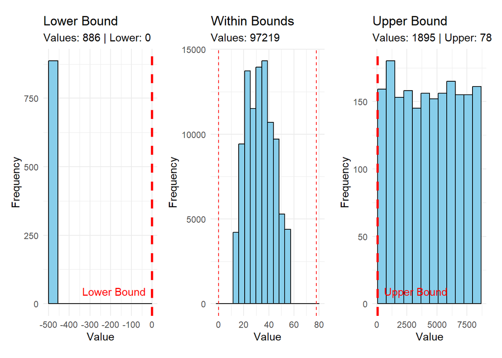

```r
df$Age <- remove_outliers(df, "Age", 2 , TRUE)
```

```
## [1] "Lower bound: 0"
## [1] "Upper bound: 78"
## [1] "Number of Outliers removed: 2781"
```

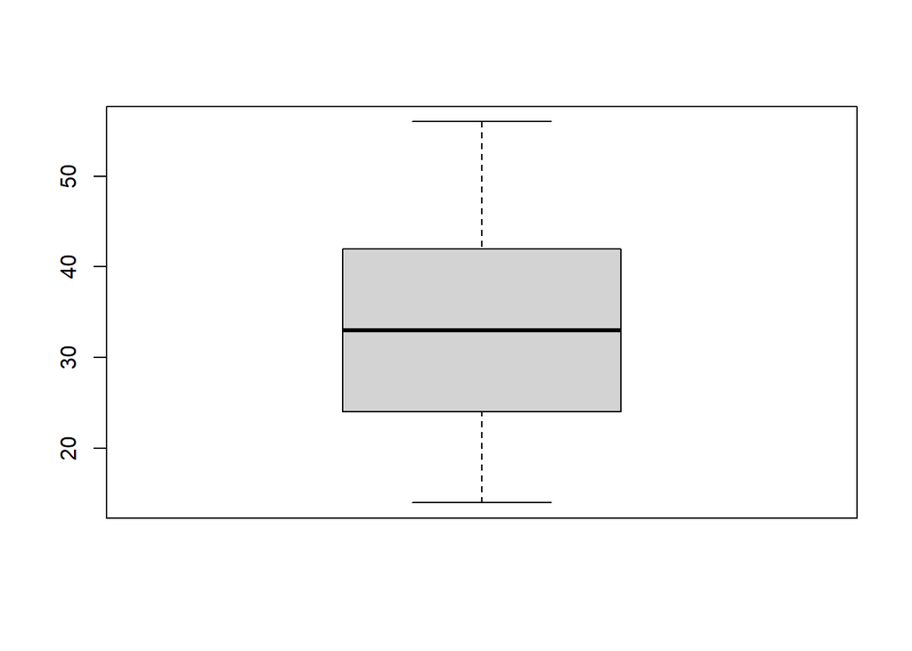

```r
boxplot(df$Age)
```

These three histograms illustrate the distribution of values of the column age categorized by their position relative to defined bounds. Each histogram provides a visual breakdown of the frequency of these values within three distinct groups: those falling below the lower bound, those within the bounds, and those exceeding the upper bound.

1. Lower Bound: The first histogram on the left represents values that fall below the lower bound. A total of 886 values are below this threshold, which is defined at 0 as indicated by the red line. The histogram shows that these values are distributed primarily in the negative range, with the majority clustering around the value -500.
2. Within Bounds: The histogram in the middle shows the distribution of values that lie within the defined lower and upper bounds. There are 97 219 values in this category. The values range between 0 and 78, as marked by the red dashed lines representing the lower and upper bounds. The distribution is approximately bell-shaped, indicating that most of the values are concentrated near the center of this range,
3. Upper Bound: The third histogram on the right displays the values exceeding the upper bound. A total of 1 895 values are greater than the upper threshold, set at 78 (depicted by the red dashed line). The histogram shows that these values extend significantly beyond the threshold, reaching into much larger values.

The information gathered from this is then used to specify the parameters in the remove_outliers function, which then replaces the outliers with NA values for further processing down the line.

### Occupation

```r
sort_mostcommon(df, "Occupation")
```

```
##       Occupation    n
## 1           <NA> 7062
## 2         Lawyer 6575
## 3      Architect 6355
## 4       Engineer 6350
## 5      Scientist 6299
## 6       Mechanic 6291
## 7     Accountant 6271
## 8      Developer 6235
## 9  Media_Manager 6232
## 10       Teacher 6215
```

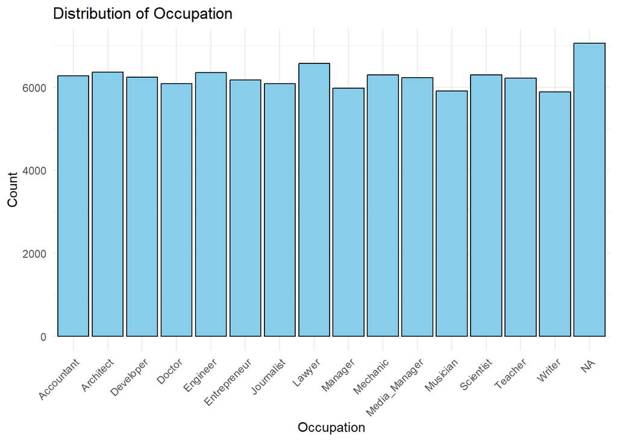

```r
categorical_plot(df, "Occupation")
```

### Annual_Income

```r
sort_nonnumeric(df, "Annual_Income")
```

```
##    Annual_Income n
## 1      14388.79_ 5
## 2      42904.26_ 5
## 3      10024.25_ 4
## 4     132643.71_ 4
## 5      132895.5_ 4
## 6      19592.58_ 4
## 7      21761.49_ 4
## 8      28381.96_ 4
## 9      33381.68_ 4
## 10     35038.35_ 4
```

```r
sort_mostcommon(df, "Annual_Income")
```

```
##    Annual_Income  n
## 1       17273.83 16
## 2       20867.67 16
## 3       36585.12 16
## 4       17816.75 15
## 5       33029.66 15
## 6        9141.63 15
## 7       95596.35 15
## 8      109945.32 14
## 9       32543.38 14
## 10      40341.16 14
```

```r
df$Annual_Income <- gsub("_", "", df$Annual_Income)
df$Annual_Income <- as.numeric(df$Annual_Income)

find_outliers(df, "Annual_Income", 2.5 , TRUE)
```

```
##    Outliers n
## 1    251889 1
## 2    265962 1
## 3    267236 1
## 4    273093 1
## 5    275234 1
## 6    277803 1
## 7    325923 1
## 8    344983 1
## 9    377503 1
## 10   378844 1
```

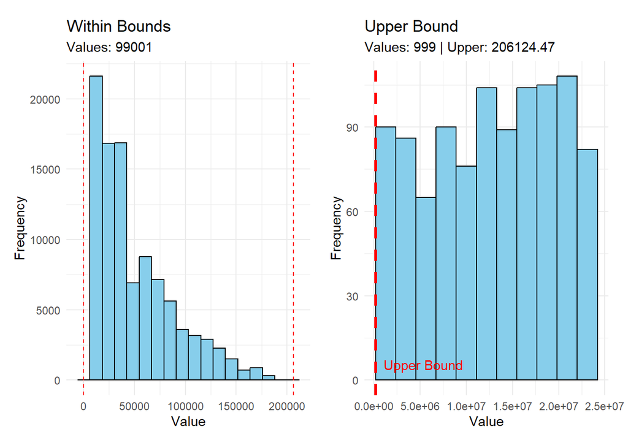

```r
df$Annual_Income <- remove_outliers(df, "Annual_Income", 2.5 , TRUE)
```

```
## [1] "Lower bound: 0"
## [1] "Upper bound: 206124.47"
## [1] "Number of Outliers removed: 999"
```

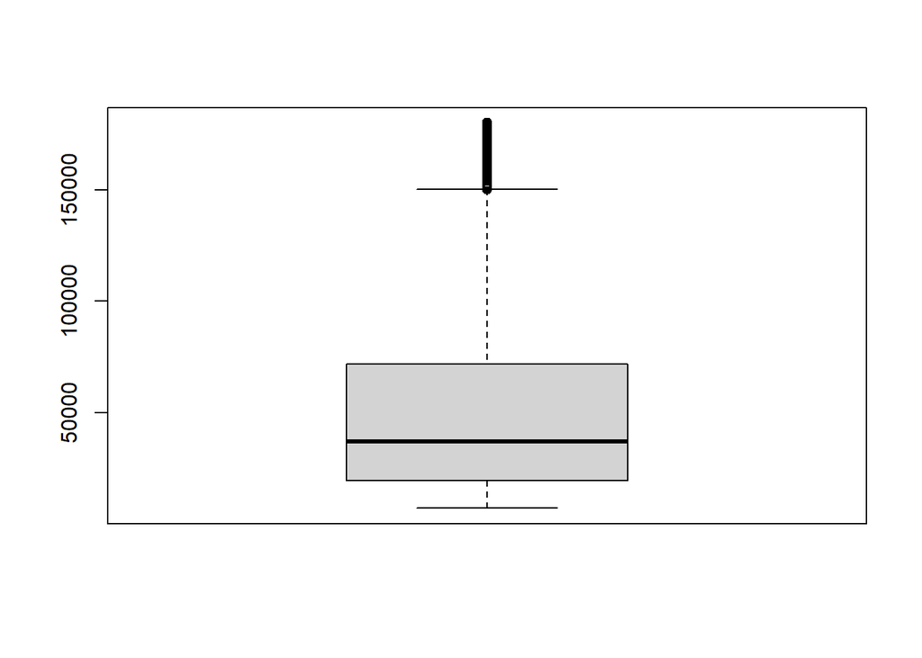

```r
boxplot(df$Annual_Income)
```

### Num_Bank_Accounts

```r
sort_nonnumeric(df, "Num_Bank_Accounts")
```

```
## [1] Num_Bank_Accounts n
## <0 Zeilen> (oder row.names mit Länge 0)
```

```r
sort_mostcommon(df, "Num_Bank_Accounts")
```

```
##    Num_Bank_Accounts     n
## 1                  6 13001
## 2                  7 12823
## 3                  8 12765
## 4                  4 12186
## 5                  5 12118
## 6                  3 11950
## 7                  9  5443
## 8                 10  5247
## 9                  1  4490
## 10                 0  4328
```

```r
df$Num_Bank_Accounts <- as.numeric(df$Num_Bank_Accounts)

find_outliers(df, "Num_Bank_Accounts", 2.5 , TRUE)
```

```
##    Outliers  n
## 1        -1 21
## 2        18  1
## 3        26  1
## 4        27  1
## 5        28  3
## 6        29  1
## 7        30  1
## 8        31  1
## 9        32  1
## 10       33  2
```

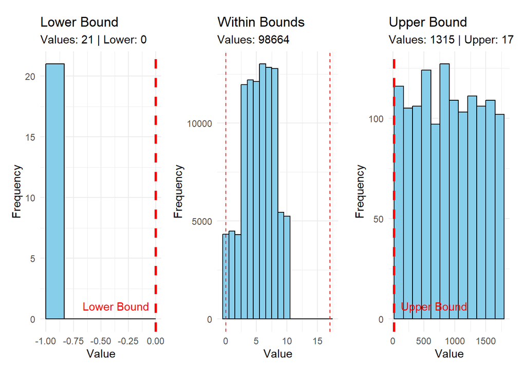

```r
df$Num_Bank_Accounts <- remove_outliers(df, "Num_Bank_Accounts", 2.5 , TRUE)
```

```
## [1] "Lower bound: 0"
## [1] "Upper bound: 17"
## [1] "Number of Outliers removed: 1336"
```

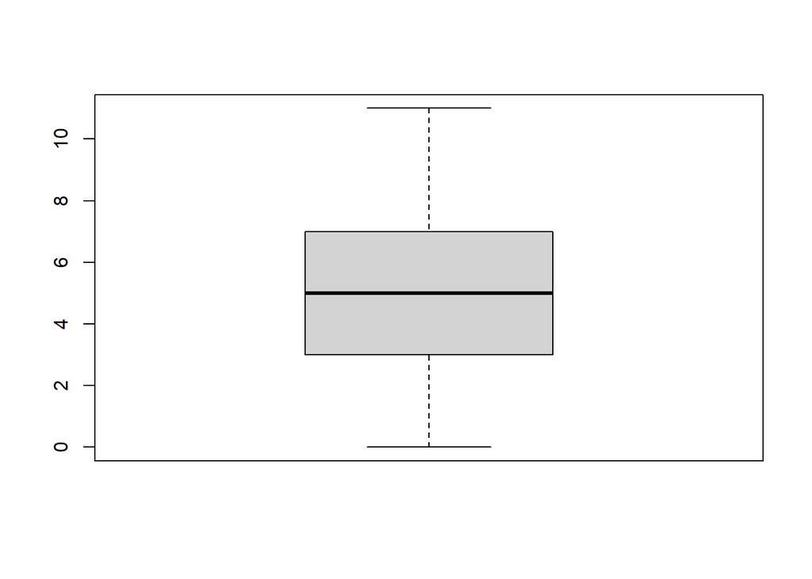

```r
boxplot(df$Num_Bank_Accounts)
```

### Interest_Rate

```r
sort_nonnumeric(df, "Interest_Rate")
```

```
## [1] Interest_Rate n
## <0 Zeilen> (oder row.names mit Länge 0)
```

```r
sort_mostcommon(df, "Interest_Rate")
```

```
##    Interest_Rate    n
## 1              8 5012
## 2              5 4979
## 3              6 4721
## 4             10 4540
## 5             12 4540
## 6              7 4494
## 7              9 4494
## 8             11 4428
## 9             18 4102
## 10            15 3992
```

```r
df$Interest_Rate <- as.numeric(df$Interest_Rate)

find_outliers(df, "Interest_Rate")
```

```
##    Outliers n
## 1        59 1
## 2        60 1
## 3        64 1
## 4        67 1
## 5        73 1
## 6        74 1
## 7        75 2
## 8        76 2
## 9        77 1
## 10       81 1
```

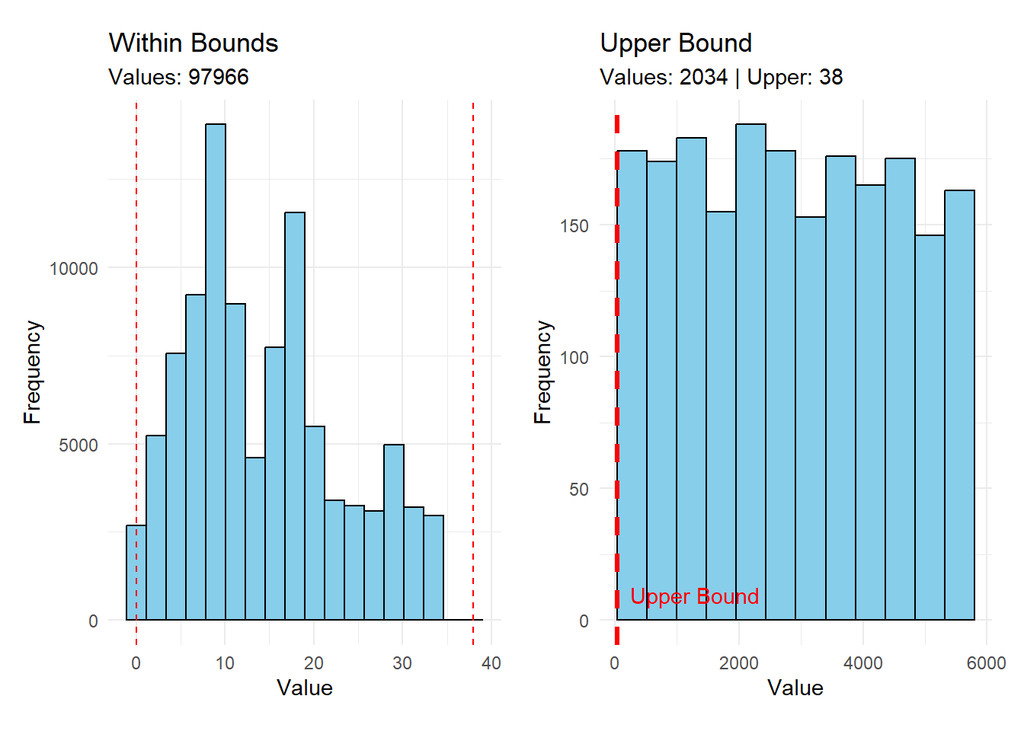

```r
df$Interest_Rate <- remove_outliers(df, "Interest_Rate")
```

```
## [1] "Lower bound: 0"
## [1] "Upper bound: 38"
## [1] "Number of Outliers removed: 2034"
```

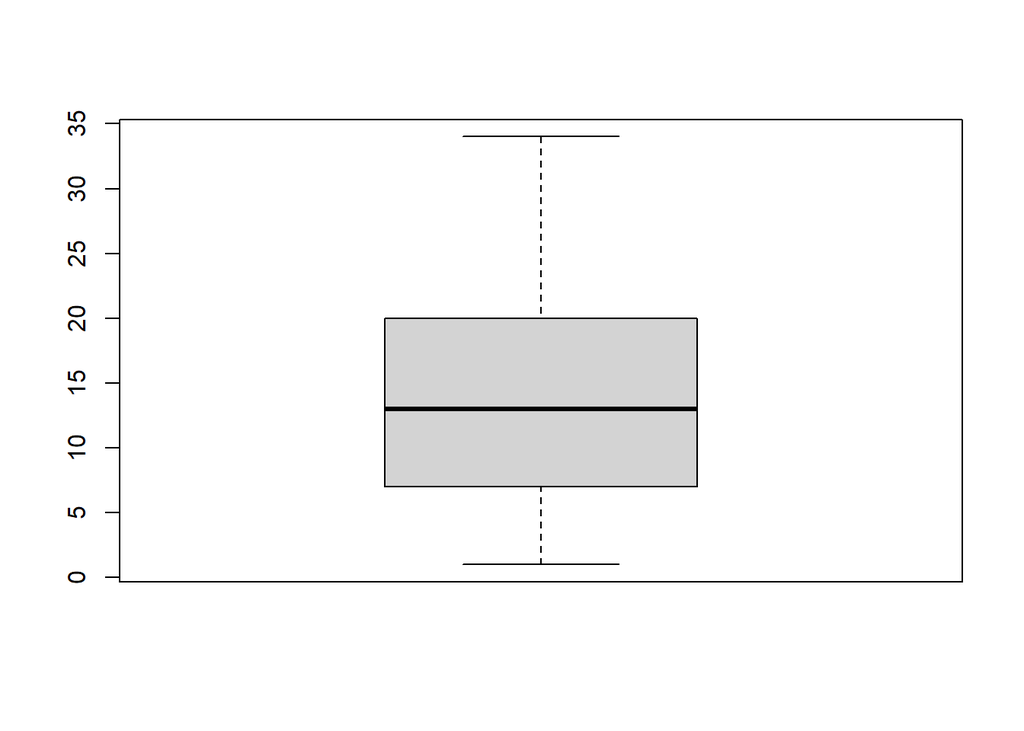

```r
boxplot(df$Interest_Rate)
```

### Num_of_Loan

```r
sort_nonnumeric(df, "Num_of_Loan")
```

```
##    Num_of_Loan   n
## 1           2_ 782
## 2           4_ 727
## 3           3_ 718
## 4           0_ 550
## 5           1_ 523
## 6           7_ 414
## 7           6_ 398
## 8           5_ 332
## 9           9_ 160
## 10          8_ 156
```

```r
sort_mostcommon(df, "Num_of_Loan")
```

```
##    Num_of_Loan     n
## 1            3 14386
## 2            2 14250
## 3            4 14016
## 4            0 10380
## 5            1 10083
## 6            6  7405
## 7            7  6930
## 8            5  6865
## 9         -100  3876
## 10           9  3542
```

```r
df$Num_of_Loan <- gsub("_", "", df$Num_of_Loan)
df$Num_of_Loan <- as.numeric(df$Num_of_Loan)

find_outliers(df, "Num_of_Loan")
```

```
##    Outliers    n
## 1      -100 3876
## 2        17    1
## 3        18    1
## 4        19    1
## 5        23    2
## 6        27    1
## 7        29    1
## 8        31    2
## 9        32    1
## 10       33    2
```

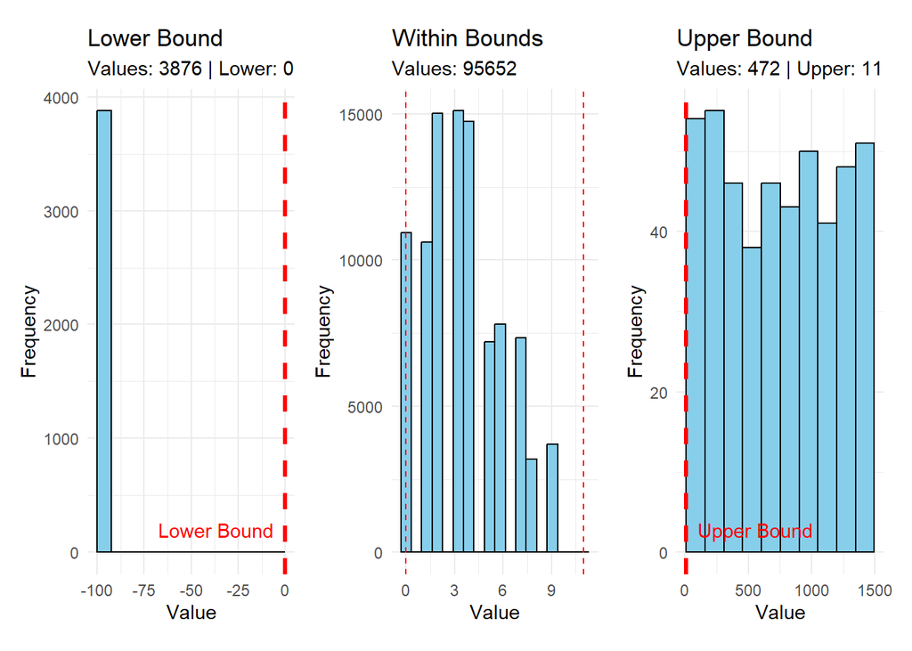

```r
df$Num_of_Loan <- remove_outliers(df, "Num_of_Loan")
```

```
## [1] "Lower bound: 0"
## [1] "Upper bound: 11"
## [1] "Number of Outliers removed: 4348"
```

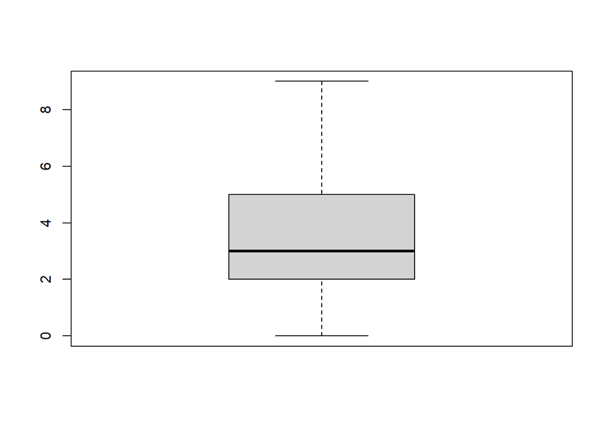

```r
boxplot(df$Num_of_Loan)
```

### Delay_from_due_date

```r
sort_nonnumeric(df, "Delay_from_due_date")
```

```
## [1] Delay_from_due_date n
## <0 Zeilen> (oder row.names mit Länge 0)
```

```r
sort_mostcommon(df, "Delay_from_due_date")
```

```
##    Delay_from_due_date    n
## 1                   15 3596
## 2                   13 3424
## 3                    8 3324
## 4                   14 3313
## 5                   10 3281
## 6                    7 3234
## 7                    9 3233
## 8                   11 3182
## 9                   12 3141
## 10                   6 3137
```

```r
df$Delay_from_due_date <- as.numeric(df$Delay_from_due_date)

find_outliers(df, "Delay_from_due_date", 3)
```

```
##   Outliers   n
## 1       -5  33
## 2       -4  62
## 3       -3 118
## 4       -2 168
## 5       -1 210
```

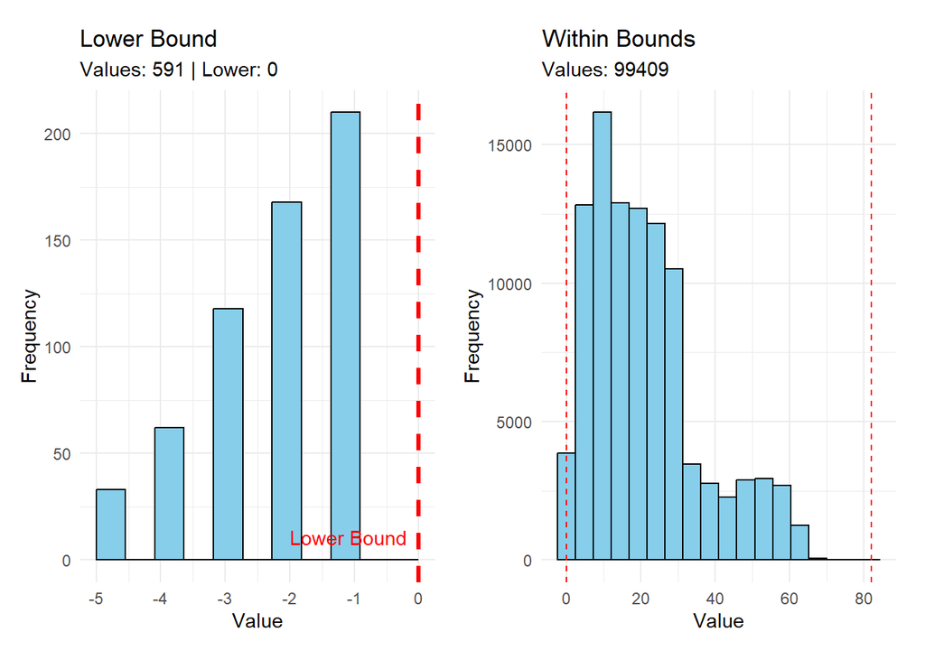

```r
df$Delay_from_due_date <- remove_outliers(df, "Delay_from_due_date", 3)
```

```
## [1] "Lower bound: 0"
## [1] "Upper bound: 82"
## [1] "Number of Outliers removed: 591"
```

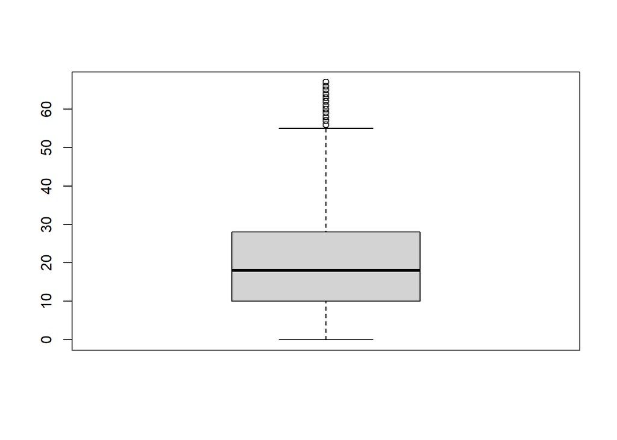

```r
boxplot(df$Delay_from_due_date)
```

### Changed_Credit_Limit

```r
sort_nonnumeric(df, "Changed_Credit_Limit")
```

```
##   Changed_Credit_Limit    n
## 1                 <NA> 2091
```

```r
sort_mostcommon(df, "Changed_Credit_Limit")
```

```
##    Changed_Credit_Limit    n
## 1                  <NA> 2091
## 2                  8.22  133
## 3                  11.5  127
## 4                 11.32  126
## 5                 10.06  121
## 6                  7.35  121
## 7                  8.23  115
## 8                 11.49  113
## 9                  7.33  110
## 10                 7.69  110
```

```r
df$Changed_Credit_Limit <- as.numeric(df$Changed_Credit_Limit)

find_outliers(df, "Changed_Credit_Limit", 2.5, FALSE)
```

```
## [1] Outliers n
## <0 Zeilen> (oder row.names mit Länge 0)
```

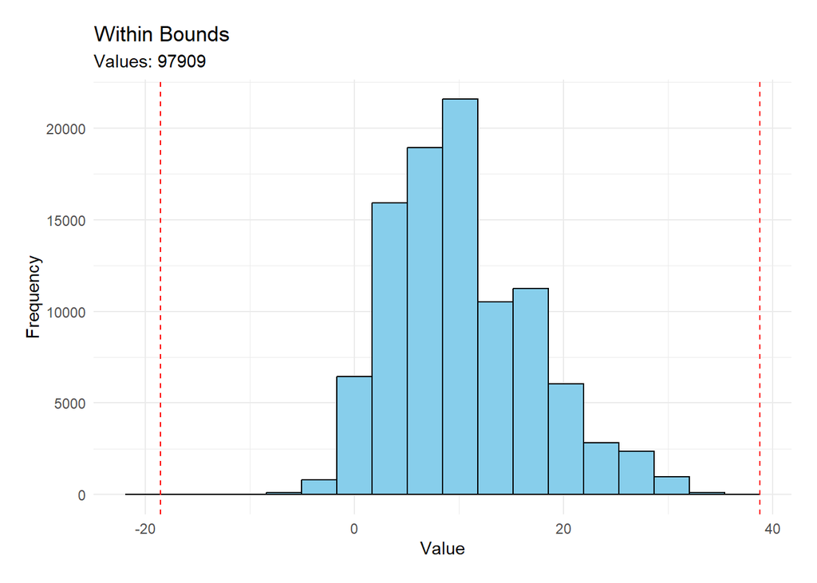

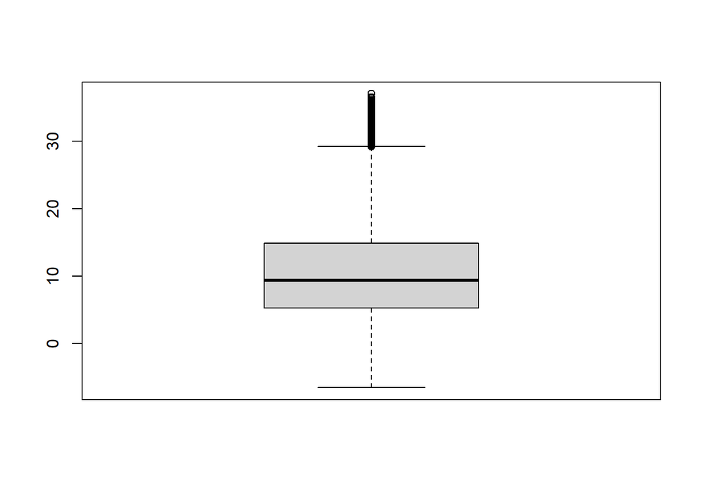

```r
boxplot(df$Changed_Credit_Limit)
```

### Num_of_Delayed_Payment

```r
sort_nonnumeric(df, "Num_of_Delayed_Payment")
```

```
##    Num_of_Delayed_Payment    n
## 1                    <NA> 7002
## 2                      8_  167
## 3                     15_  160
## 4                     10_  156
## 5                     12_  154
## 6                     19_  154
## 7                     20_  154
## 8                     17_  151
## 9                      9_  147
## 10                    11_  143
```

```r
sort_mostcommon(df, "Num_of_Delayed_Payment")
```

```
##    Num_of_Delayed_Payment    n
## 1                    <NA> 7002
## 2                      19 5327
## 3                      17 5261
## 4                      16 5173
## 5                      10 5153
## 6                      18 5083
## 7                      15 5077
## 8                      20 4935
## 9                      12 4905
## 10                      9 4834
```

```r
df$Num_of_Delayed_Payment <- gsub("_", "", df$Num_of_Delayed_Payment)
df$Num_of_Delayed_Payment <- as.numeric(df$Num_of_Delayed_Payment)

find_outliers(df, "Num_of_Delayed_Payment")
```

```
##    Outliers   n
## 1        -3  94
## 2        -2 234
## 3        -1 316
## 4        46   1
## 5        47   1
## 6        49   1
## 7        52   1
## 8        72   1
## 9        80   1
## 10       84   1
```

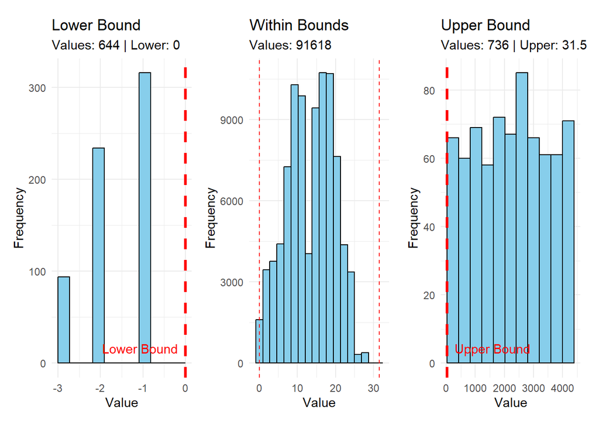

```r
df$Num_of_Delayed_Payment <- remove_outliers(df, "Num_of_Delayed_Payment")
```

```
## [1] "Lower bound: 0"
## [1] "Upper bound: 31.5"
## [1] "Number of Outliers removed: 1380"
```

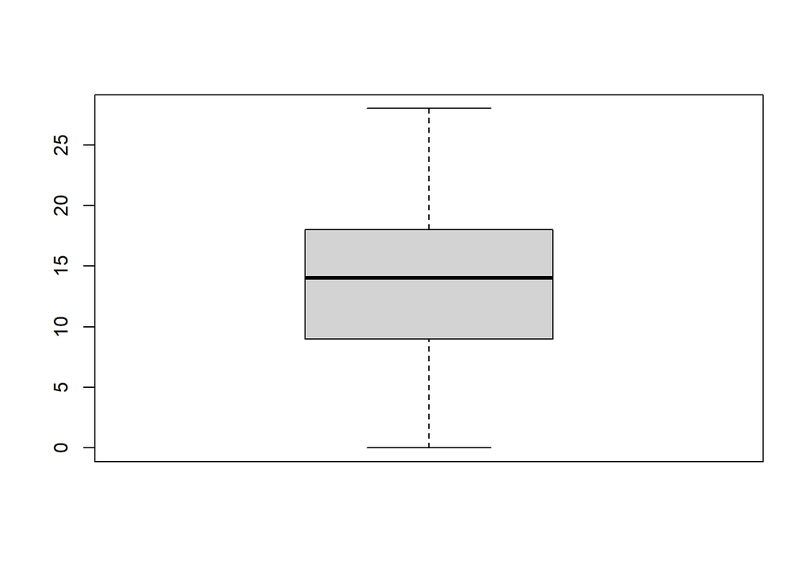

```r
boxplot(df$Num_of_Delayed_Payment)
```

### Num_Credit_Inquiries

```r
sort_nonnumeric(df, "Num_Credit_Inquiries")
```

```
##   Num_Credit_Inquiries    n
## 1                   NA 1965
```

```r
sort_mostcommon(df, "Num_Credit_Inquiries")
```

```
##    Num_Credit_Inquiries     n
## 1                     4 11271
## 2                     3  8890
## 3                     6  8111
## 4                     7  8058
## 5                     2  8028
## 6                     8  7866
## 7                     1  7588
## 8                     0  6972
## 9                     5  5693
## 10                    9  5283
```

```r
df$Num_Credit_Inquiries <- as.numeric(df$Num_Credit_Inquiries)

find_outliers(df, "Num_Credit_Inquiries", 3)
```

```
##    Outliers n
## 1        29 1
## 2        31 4
## 3        32 2
## 4        33 1
## 5        34 1
## 6        37 1
## 7        43 1
## 8        45 1
## 9        46 2
## 10       49 1
```

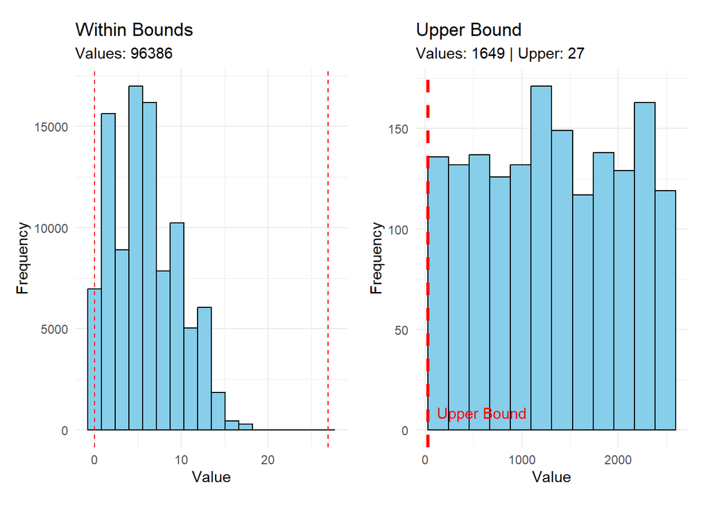

```r
df$Num_Credit_Inquiries <- remove_outliers(df, "Num_Credit_Inquiries", 3)
```

```
## [1] "Lower bound: 0"
## [1] "Upper bound: 27"
## [1] "Number of Outliers removed: 1649"
```

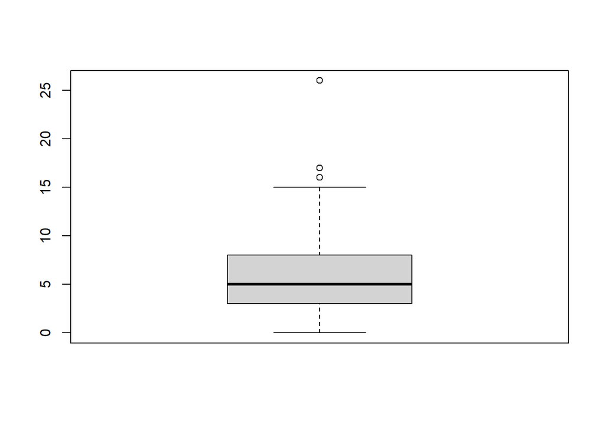

```r
boxplot(df$Num_Credit_Inquiries)
```

### Credit_Mix

```r
sort_mostcommon(df, "Credit_Mix")
```

```
##   Credit_Mix     n
## 1   Standard 36479
## 2       Good 24337
## 3       <NA> 20195
## 4        Bad 18989
```

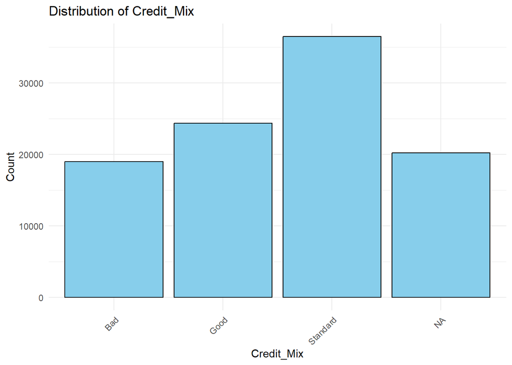

```r
categorical_plot(df, "Credit_Mix")
```

### Outstanding_Debt

```r
sort_nonnumeric(df, "Outstanding_Debt")
```

```
##    Outstanding_Debt n
## 1           396.97_ 3
## 2          1048.02_ 2
## 3          1054.86_ 2
## 4          1075.37_ 2
## 5          1172.87_ 2
## 6          1179.95_ 2
## 7          1287.97_ 2
## 8          1450.47_ 2
## 9           188.33_ 2
## 10         2150.61_ 2
```

```r
sort_mostcommon(df, "Outstanding_Debt")
```

```
##    Outstanding_Debt  n
## 1           1360.45 24
## 2           1109.03 23
## 3            1151.7 23
## 4            460.46 23
## 5              0.95 16
## 6             10.29 16
## 7             100.3 16
## 8           1004.26 16
## 9            101.29 16
## 10          1024.56 16
```

```r
df$Outstanding_Debt <- gsub("_", "", df$Outstanding_Debt)
df$Outstanding_Debt <- as.numeric(df$Outstanding_Debt)

find_outliers(df, "Outstanding_Debt", 2.5)
```

```
## [1] Outliers n
## <0 Zeilen> (oder row.names mit Länge 0)
```

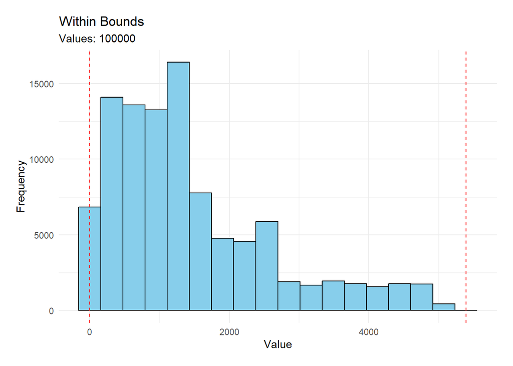

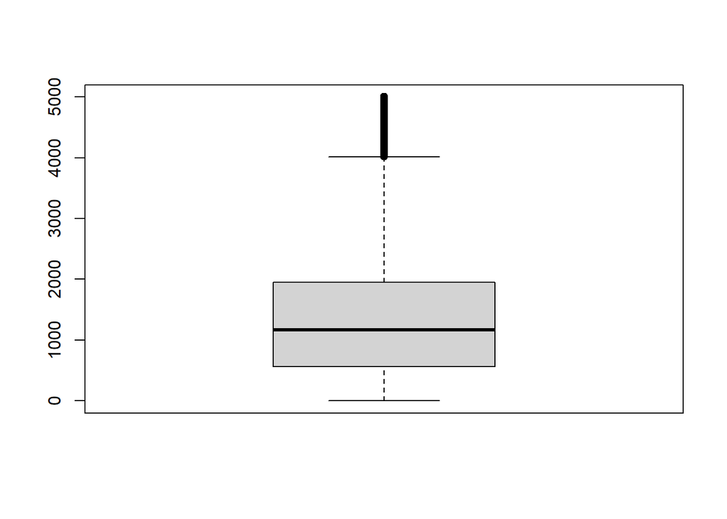

```r
boxplot(df$Outstanding_Debt)
```

### Credit_Utilization_Ratio

```r
sort_nonnumeric(df, "Credit_Utilization_Ratio")
```

```
## [1] Credit_Utilization_Ratio n
## <0 Zeilen> (oder row.names mit Länge 0)
```

```r
sort_mostcommon(df, "Credit_Utilization_Ratio")
```

```
##    Credit_Utilization_Ratio n
## 1                  20.00000 1
## 2                  20.10077 1
## 3                  20.17294 1
## 4                  20.24413 1
## 5                  20.25707 1
## 6                  20.71975 1
## 7                  20.83095 1
## 8                  20.83249 1
## 9                  20.88008 1
## 10                 20.88125 1
```

```r
df$Credit_Utilization_Ratio <- as.numeric(df$Credit_Utilization_Ratio)

find_outliers(df, "Credit_Utilization_Ratio")
```

```
##   Outliers n
## 1 49.25498 1
## 2 49.52232 1
## 3 49.56452 1
## 4 50.00000 1
```

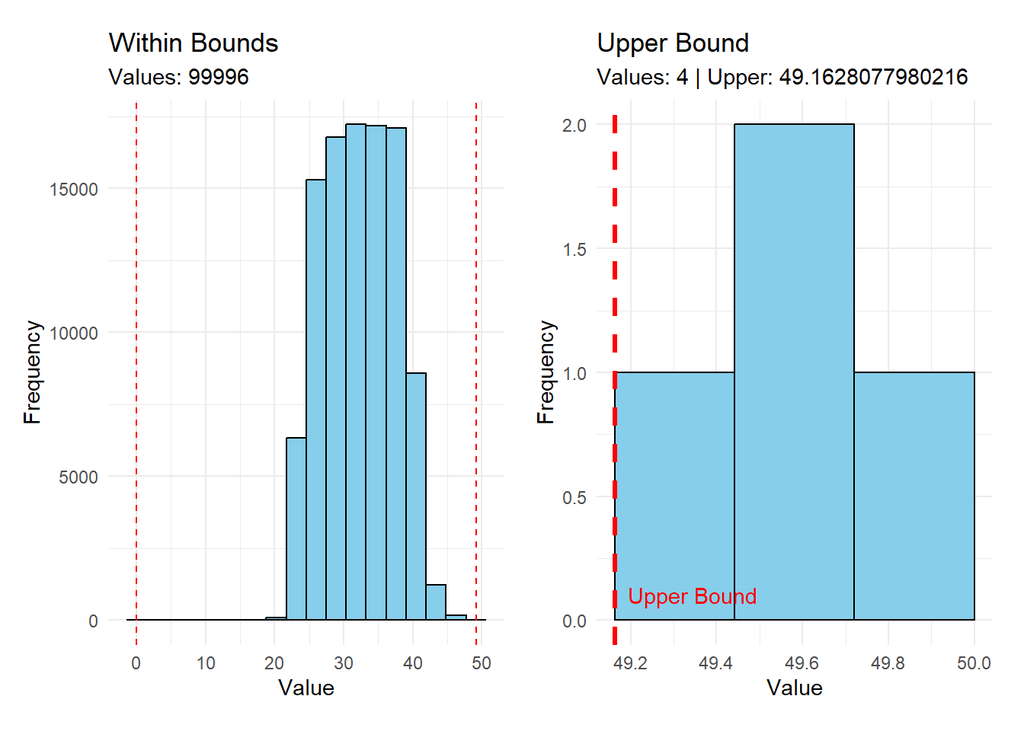

```r
df$Credit_Utilization_Ratio <- remove_outliers(df, "Credit_Utilization_Ratio")
```

```
## [1] "Lower bound: 0"
## [1] "Upper bound: 49.1628077980216"
## [1] "Number of Outliers removed: 4"
```

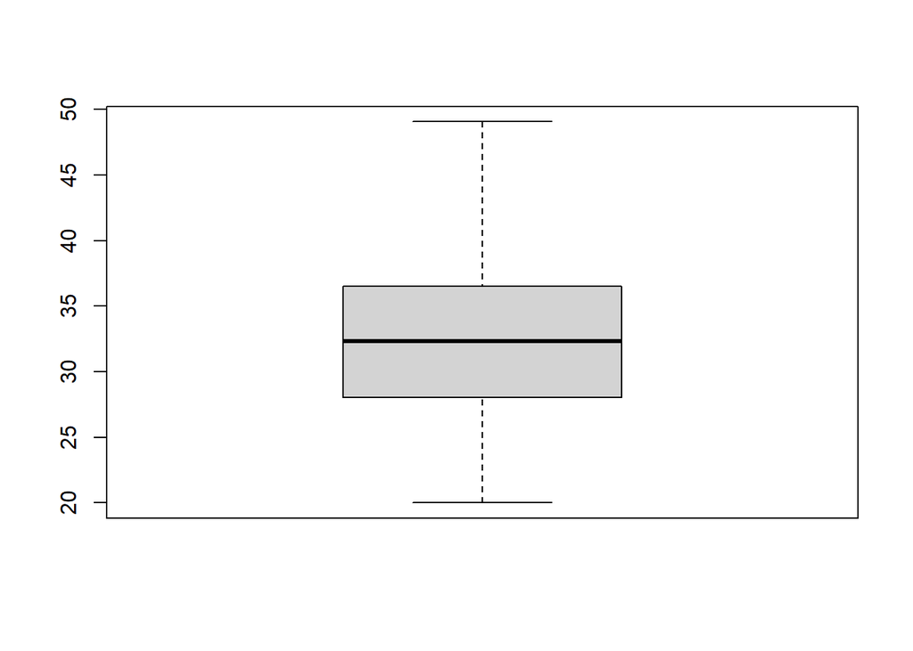

```r
boxplot(df$Credit_Utilization_Ratio)
```

### Credit_History_Age

Currently the data is in a text format. For further analysis and model building, the time should be displayed in months (as a number).

```r
sort_mostcommon(df, "Credit_History_Age")
```

```
##        Credit_History_Age    n
## 1                    <NA> 9030
## 2  15 Years and 11 Months  446
## 3   19 Years and 4 Months  445
## 4   19 Years and 5 Months  444
## 5  17 Years and 11 Months  443
## 6   19 Years and 3 Months  441
## 7   17 Years and 9 Months  438
## 8  15 Years and 10 Months  436
## 9  17 Years and 10 Months  435
## 10  15 Years and 9 Months  432
```

```r
library(stringr)
# Change time into number of months
df <- df %>%
  mutate(
    Credit_History_Age = as.numeric(str_extract(Credit_History_Age, "\\d+(?=\\sYears)")) * 12 +
                         as.numeric(str_extract(Credit_History_Age, "\\d+(?=\\sMonths)"))
  )

sort_mostcommon(df, "Credit_History_Age")
```

```
##    Credit_History_Age    n
## 1                  NA 9030
## 2                 191  446
## 3                 232  445
## 4                 233  444
## 5                 215  443
## 6                 231  441
## 7                 213  438
## 8                 190  436
## 9                 214  435
## 10                189  432
```

```
## [1] Outliers n
## <0 Zeilen> (oder row.names mit Länge 0)
```

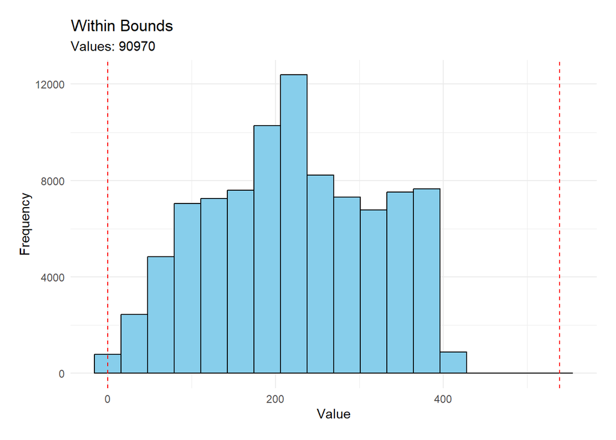

```r
df$Credit_History_Age <- as.numeric(df$Credit_History_Age)
find_outliers(df, "Credit_History_Age")
```

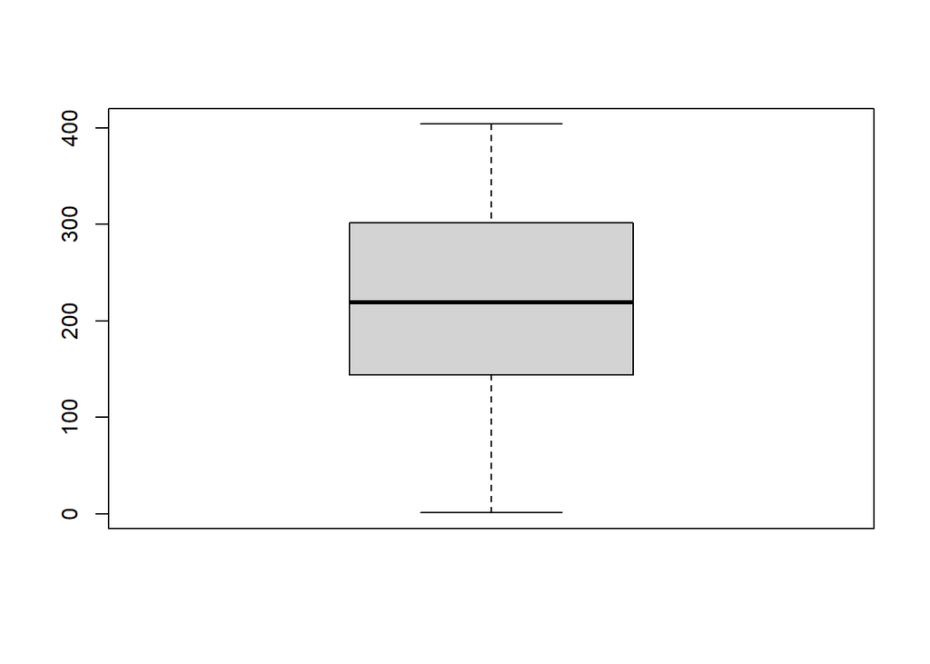

```r
boxplot(df$Credit_History_Age)
```

### Payment_of_Min_Amount

```r
sort_mostcommon(df, "Payment_of_Min_Amount")
```

```
##   Payment_of_Min_Amount     n
## 1                   Yes 52326
## 2                    No 35667
## 3                  <NA> 12007
```

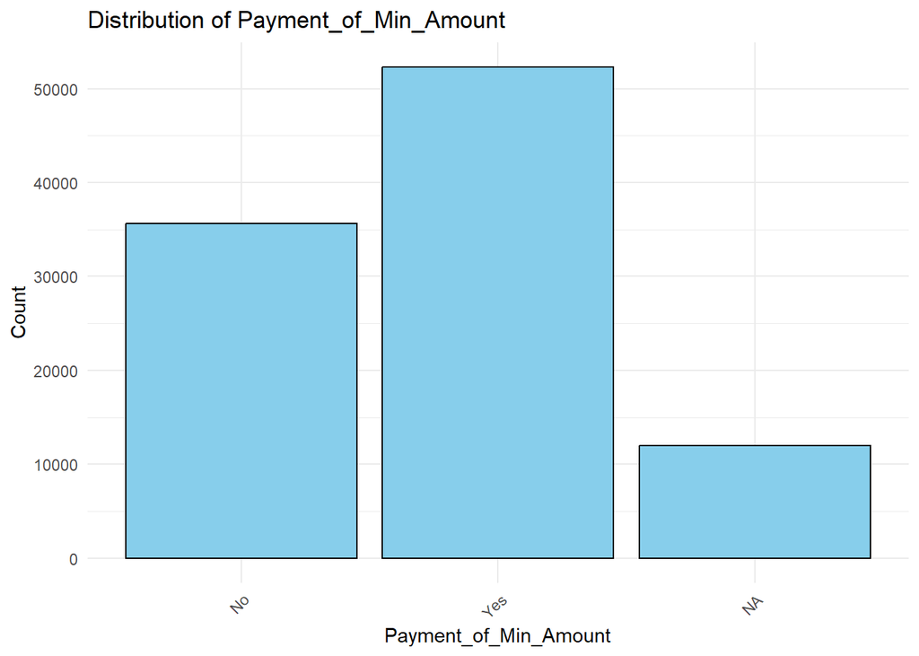

```r
categorical_plot(df, "Payment_of_Min_Amount")
```

### Total_EMI_per_month

```r
sort_nonnumeric(df, "Total_EMI_per_month")
```

```
## [1] Total_EMI_per_month n
## <0 Zeilen> (oder row.names mit Länge 0)
```

```r
sort_mostcommon(df, "Total_EMI_per_month")
```

```
##    Total_EMI_per_month     n
## 1             0.000000 10613
## 2             4.462837     8
## 3             4.713184     8
## 4             4.865690     8
## 5             4.916139     8
## 6             5.138485     8
## 7             5.218466     8
## 8             5.262291     8
## 9             5.629824     8
## 10            5.711417     8
```

```r
df$Total_EMI_per_month <- as.numeric(df$Total_EMI_per_month)

find_outliers(df, "Total_EMI_per_month", 9)
```

```
##    Outliers n
## 1  1349.000 1
## 2  1349.081 2
## 3  1357.000 1
## 4  1386.000 1
## 5  1396.000 1
## 6  1435.128 4
## 7  1436.000 1
## 8  1439.000 1
## 9  1466.974 1
## 10 1468.000 1
```

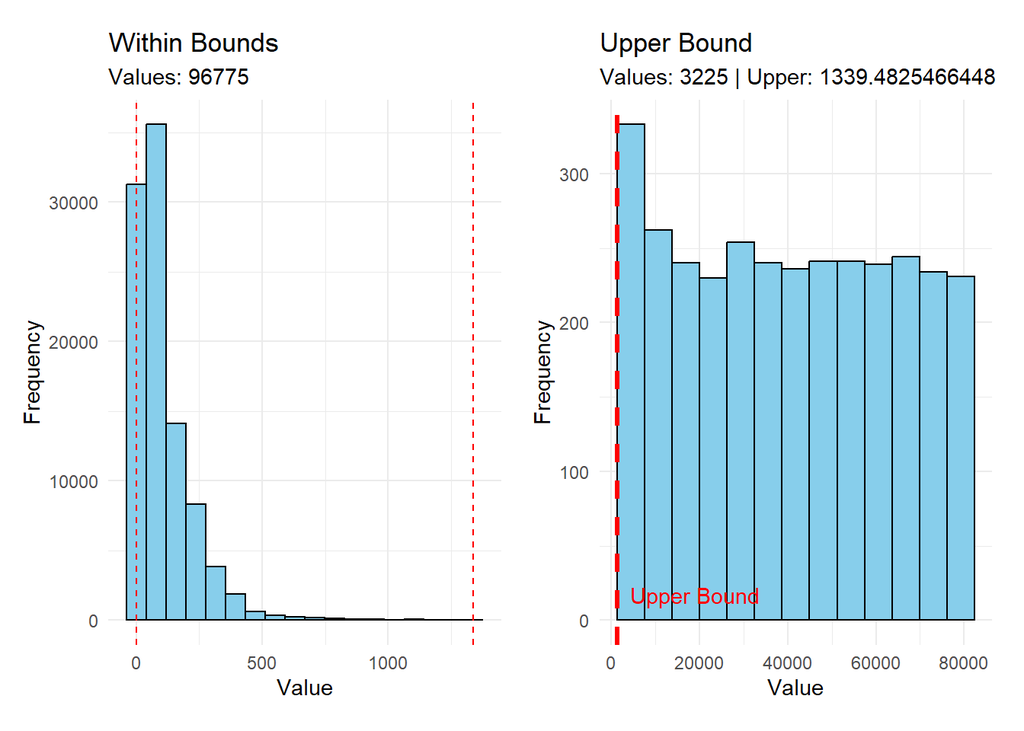

```r
df$Total_EMI_per_month <- remove_outliers(df, "Total_EMI_per_month", 9)
```

```
## [1] "Lower bound: 0"
## [1] "Upper bound: 1339.4825466448"
## [1] "Number of Outliers removed: 3225"
```

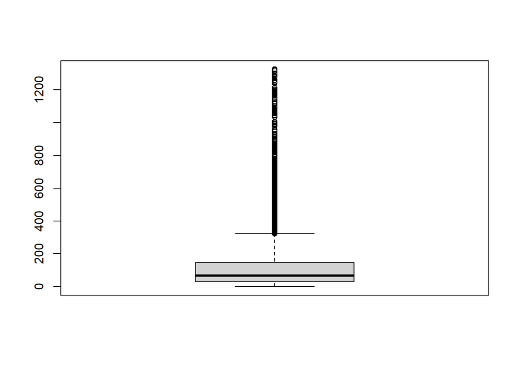

```r
boxplot(df$Total_EMI_per_month)
```

### Amount_invested_monthly

```r
sort_nonnumeric(df, "Amount_invested_monthly")
```

```
##   Amount_invested_monthly    n
## 1                    <NA> 8784
```

```r
sort_mostcommon(df, "Amount_invested_monthly")
```

```
##    Amount_invested_monthly    n
## 1                     <NA> 8784
## 2                      0.0  169
## 3       10.010194262612963    1
## 4       10.011424795004293    1
## 5        10.03659960594723    1
## 6       10.053768350640556    1
## 7       10.068234588368787    1
## 8       10.071936767841647    1
## 9       10.107546903087657    1
## 10       10.11661404301702    1
```

```r
df$Amount_invested_monthly <- as.numeric(df$Amount_invested_monthly)

find_outliers(df, "Amount_invested_monthly",5)
```

```
##    Outliers n
## 1  1059.728 1
## 2  1059.866 1
## 3  1060.040 1
## 4  1060.074 1
## 5  1060.074 1
## 6  1060.345 1
## 7  1060.388 1
## 8  1060.434 1
## 9  1060.592 1
## 10 1061.116 1
```

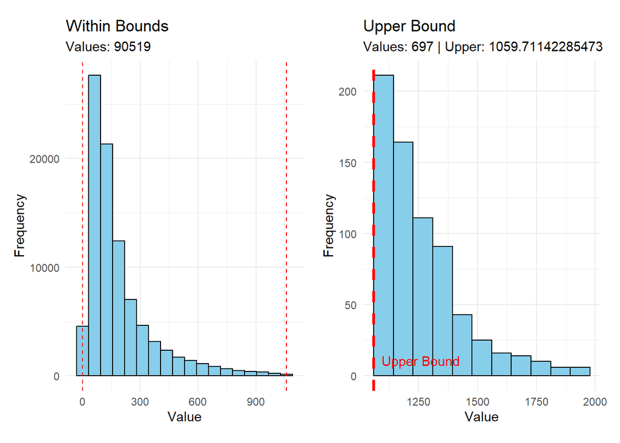

```r
df$Amount_invested_monthly <- remove_outliers(df, "Amount_invested_monthly", 5)
```

```
## [1] "Lower bound: 0"
## [1] "Upper bound: 1059.71142285473"
## [1] "Number of Outliers removed: 697"
```

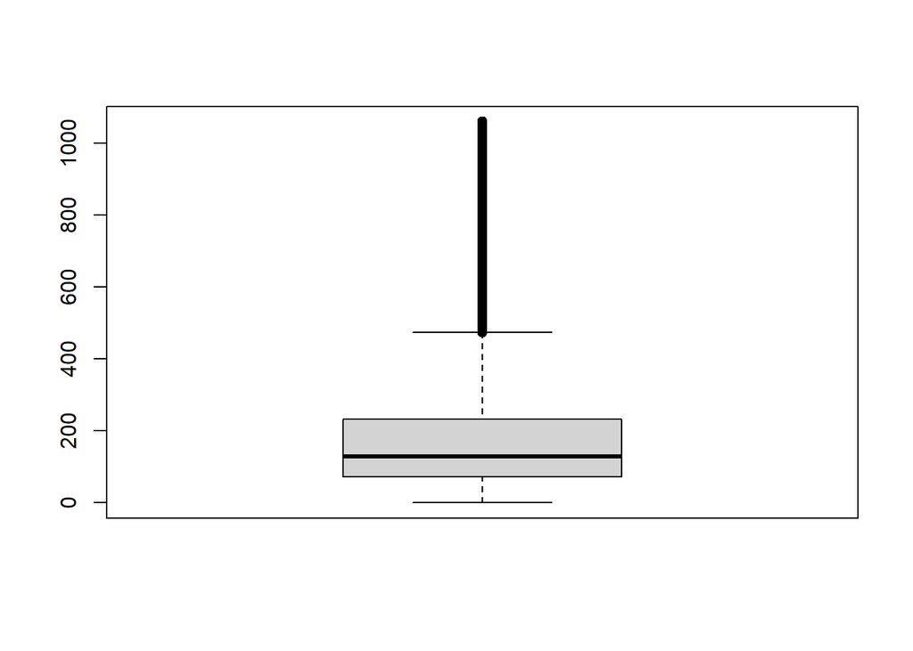

```r
boxplot(df$Amount_invested_monthly)
```

### Payment_Behaviour

```r
sort_mostcommon(df, "Payment_Behaviour")
```

```
##                  Payment_Behaviour     n
## 1   Low_spent_Small_value_payments 25513
## 2 High_spent_Medium_value_payments 17540
## 3  Low_spent_Medium_value_payments 13861
## 4  High_spent_Large_value_payments 13721
## 5  High_spent_Small_value_payments 11340
## 6   Low_spent_Large_value_payments 10425
## 7                             <NA>  7600
```

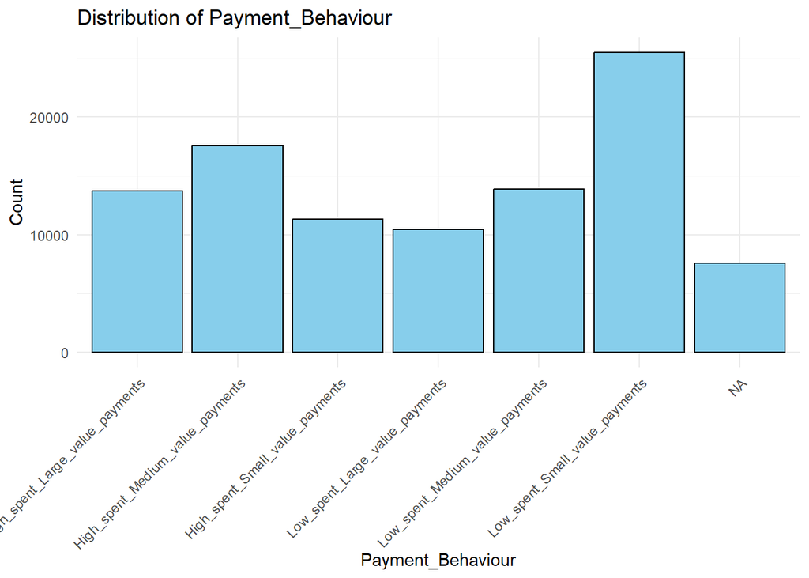

```r
categorical_plot(df, "Payment_Behaviour")
```

### Monthly_Balance

```r
sort_nonnumeric(df, "Monthly_Balance")
```

```
##   Monthly_Balance    n
## 1            <NA> 1209
```

```r
sort_mostcommon(df, "Monthly_Balance")
```

```
##         Monthly_Balance    n
## 1                  <NA> 1209
## 2  0.007759664775335295    1
## 3   0.08862786534905354    1
## 4   0.09548249601976977    1
## 5   0.13113565109563294    1
## 6     0.366147079459779    1
## 7    0.3825579787828133    1
## 8    0.4191236107922123    1
## 9    0.4534564914083034    1
## 10   0.5035823529403842    1
```

```r
df$Monthly_Balance <- as.numeric(df$Monthly_Balance)

find_outliers(df, "Monthly_Balance", 5)
```

```
##    Outliers n
## 1  1473.795 1
## 2  1474.356 1
## 3  1475.986 1
## 4  1477.672 1
## 5  1478.421 1
## 6  1482.780 1
## 7  1486.737 1
## 8  1490.570 1
## 9  1496.215 1
## 10 1497.942 1
```

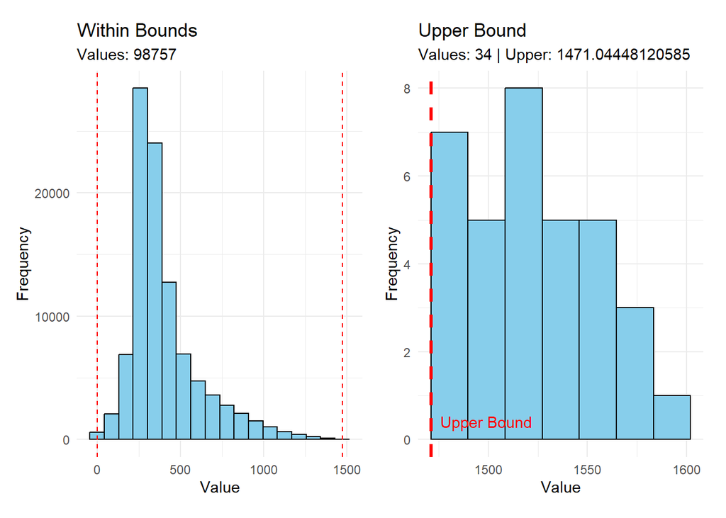

```r
df$Monthly_Balance <- remove_outliers(df, "Monthly_Balance", 5)
```

```
## [1] "Lower bound: 0"
## [1] "Upper bound: 1471.04448120585"
## [1] "Number of Outliers removed: 34"
```

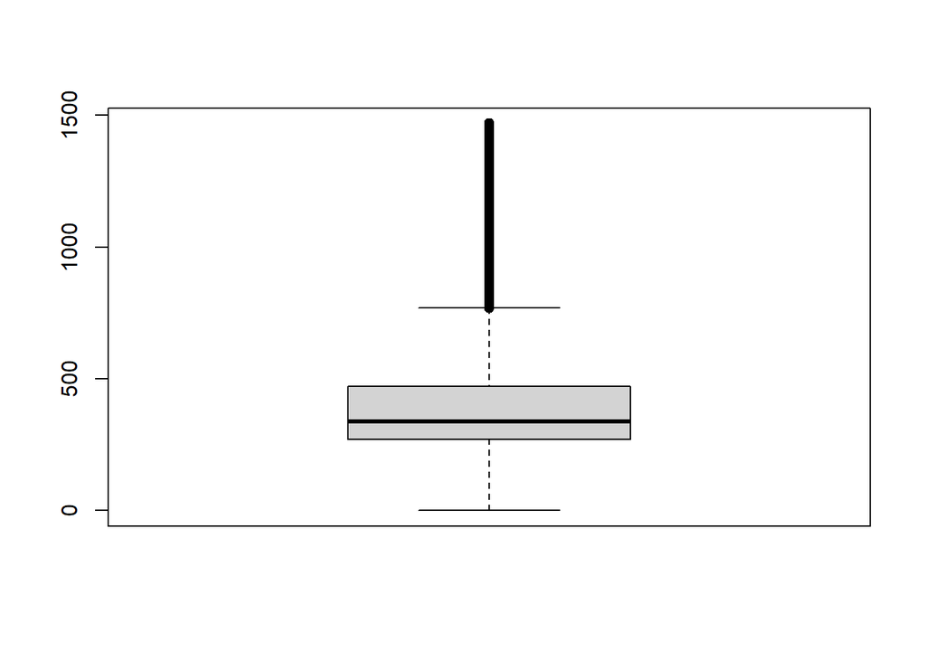

```r
boxplot(df$Monthly_Balance)
```

### Credit_Score

```r
sort_mostcommon(df, "Credit_Score")
```

```
##   Credit_Score     n
## 1     Standard 53174
## 2         Poor 28998
## 3         Good 17828
```

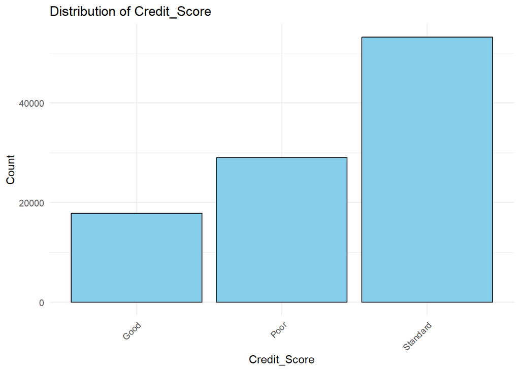

```r
categorical_plot(df, "Credit_Score")
```

## NA Imputation

In all the columns that contain NA’s the missing values have to be imputed.

```r
colSums(is.na(df))
```

```
##              Customer_ID                      Age               Occupation
##                        0                     2781                     7062
##            Annual_Income        Num_Bank_Accounts            Interest_Rate
##                      999                     1336                     2034
##              Num_of_Loan      Delay_from_due_date   Num_of_Delayed_Payment
##                     4348                      591                     8382
##     Changed_Credit_Limit     Num_Credit_Inquiries               Credit_Mix
##                     2091                     3614                    20195
##         Outstanding_Debt Credit_Utilization_Ratio       Credit_History_Age
##                        0                        4                     9030
##    Payment_of_Min_Amount      Total_EMI_per_month  Amount_invested_monthly
##                    12007                     3225                     9481
##        Payment_Behaviour          Monthly_Balance             Credit_Score
##                     7600                     1243                        0
```

**The dataset is special in this regard, because it contains the credit score values of multiple people. For each person there are 8 entries and they are identifiable by the Customer_ID. Missing values can be imputed on a per-customer basis, which helps maintain the integrity of the data.**

Depending on the variable there are 2 options:

Mean Imputation or Mode Imputation

Following this procedure for each Customer_ID (Customer):

1. if all values are NA’s -> we drop the customer
2. for each customer we get either:
   1. the mean or
   2. the mode
3. we replace the NA with the imputation value

Let’s do this in code with functions for mean and mode imputation:

```r
library(dplyr)

mean_impute <- function(data, column, rounding = FALSE) {
  data <- data %>%
    group_by(Customer_ID) %>%
    filter(!all(is.na(!!sym(column)))) %>%
    mutate(
      !!sym(column) := if_else(
        is.na(!!sym(column)),
        if (rounding) round(mean(!!sym(column), na.rm = TRUE)) else mean(!!sym(column), na.rm = TRUE),
        !!sym(column)
      )
    ) %>%
    ungroup()
  return(data)
}

mode_impute <- function(data, column) {
  get_mode <- function(x) {
    ux <- unique(na.omit(x))
    ux[which.max(tabulate(match(x, ux)))]
  }

  data <- data %>%
    group_by(Customer_ID) %>%
    filter(!all(is.na(!!sym(column)))) %>%
    mutate(
      !!sym(column) := if_else(
        is.na(!!sym(column)),
        get_mode(!!sym(column)),
        !!sym(column)
      )
    ) %>%
    ungroup()
  return(data)
}
```

### Mode Imputation

For the Categorical variables mode imputation is the right method:

- Occupation
- Credit_Mix
- Payment_of_Min_Amount
- Payment_Behaviour

```r
df <- mode_impute(df, "Occupation")
df <- mode_impute(df, "Credit_Mix")
df <- mode_impute(df, "Payment_of_Min_Amount")
df <- mode_impute(df, "Payment_Behaviour")
```

### Mean Imputation

For the numeric variables we do mean imputation.

**The integer values are kept as integer by rounding the resulting value:**

- Age
- Num_Bank_Accounts
- Num_of_Loan
- Delay_from_due_date
- Num_of_Delayed_Payment
- Num_Credit_Inquiries
- Credit_History_Age

**For the other numeric variables, no rounding is needed:**

- Annual_Income
- Interest_Rate
- Changed_Credit_Limit Credit_Utilization_Ratio
- Total_EMI_per_month
- Amount_invested_monthly
- Monthly_Balance

```r
#with rounding
df <- mean_impute(df, "Age", TRUE)
df$Age <- as.integer(df$Age)
df <- mean_impute(df, "Num_Bank_Accounts", TRUE)
df$Num_Bank_Accounts <- as.integer(df$Num_Bank_Accounts)
df <- mean_impute(df, "Num_of_Loan", TRUE)
df$Num_of_Loan <- as.integer(df$Num_of_Loan)
df <- mean_impute(df, "Delay_from_due_date", TRUE)
df$Delay_from_due_date <- as.integer(df$Delay_from_due_date)
df <- mean_impute(df, "Num_of_Delayed_Payment", TRUE)
df$Num_of_Delayed_Payment <- as.integer(df$Num_of_Delayed_Payment)
df <- mean_impute(df, "Num_Credit_Inquiries", TRUE)
df$Num_Credit_Inquiries <- as.integer(df$Num_Credit_Inquiries)
df <- mean_impute(df, "Credit_History_Age", TRUE)
df$Credit_History_Age <- as.integer(df$Credit_History_Age)

#without rounding (default = FALSE)
df <- mean_impute(df, "Annual_Income")
df <- mean_impute(df, "Interest_Rate")
df <- mean_impute(df, "Changed_Credit_Limit")
df <- mean_impute(df, "Credit_Utilization_Ratio")
df <- mean_impute(df, "Total_EMI_per_month")
df <- mean_impute(df, "Amount_invested_monthly")
df <- mean_impute(df, "Monthly_Balance")
```

Let’s check again, if all NA’s were imputed…

…and yes 0 NA’s are left in the dataset.

```r
colSums(is.na(df))
```

```
##              Customer_ID                      Age               Occupation
##                        0                        0                        0
##            Annual_Income        Num_Bank_Accounts            Interest_Rate
##                        0                        0                        0
##              Num_of_Loan      Delay_from_due_date   Num_of_Delayed_Payment
##                        0                        0                        0
##     Changed_Credit_Limit     Num_Credit_Inquiries               Credit_Mix
##                        0                        0                        0
##         Outstanding_Debt Credit_Utilization_Ratio       Credit_History_Age
##                        0                        0                        0
##    Payment_of_Min_Amount      Total_EMI_per_month  Amount_invested_monthly
##                        0                        0                        0
##        Payment_Behaviour          Monthly_Balance             Credit_Score
##                        0                        0                        0
```

## Data Preparation

“Customer_ID” has done its job and can now be removed, as it is no longer needed.

```r
library(dplyr)

df <- df %>% dplyr::select(-Customer_ID)
```

The categorical variables need to be turned into factors for further use. Some variable names are also shortened, with the changes visible in the code cell below.

```r
df_copy <- df

# Factor Categorical Variables
df$Occupation <- factor(df$Occupation)
df$Credit_Mix <- factor(df$Credit_Mix, levels = c("Bad", "Standard", "Good"), labels = c("Poor", "Standard", "Good"))
df$Payment_of_Min_Amount <- factor(df$Payment_of_Min_Amount)
df$Payment_Behaviour <- factor(df$Payment_Behaviour, levels = c("Low_spent_Small_value_payments", "Low_spent_Medium_value_payments", "Low_spent_Large_value_payments","High_spent_Small_value_payments","High_spent_Medium_value_payments","High_spent_Large_value_payments"), labels = c("LowSpent_SmallValue", "LowSpent_MediumValue", "LowSpent_LargeValue", "HighSpent_SmallValue", "HighSpent_MediumValue", "HighSpent_LargeValue"))
df$Credit_Score <- factor(df$Credit_Score, levels = c("Poor", "Standard", "Good"))

# Change Column Names
colnames(df) <- c("Age",
                  "Occupation",
                  "Annual_Income",
                  "Bank_Accounts",       # Num_Bank_Accounts
                  "Interest_Rate",
                  "Loans",               # Num_of_Loan
                  "Days_Delayed",        # Delay_from_due_date
                  "Payments_Delayed",    # Num_of_Delayed_Payment
                  "Credit_Limit_Change", # Changed_Credit_Limit
                  "Credit_Inquiries",    # Num_Credit_Inquiries
                  "Credit_Mix",
                  "Outstanding_Debt",
                  "Credit_Utilization",  # Credit_Utilization_Ratio
                  "Credit_History",      # Credit_History_Age
                  "Min_Payment",         # Payment_of_Min_Amount
                  "Monthly_EMI",         # Total_EMI_per_month
                  "Monthly_Invested",    # Amount_invested_monthly
                  "Payment_Behaviour",
                  "Balance",             # Monthly_Balance
                  "Credit_Score")

str(df)
```

```
## tibble [100,000 × 20] (S3: tbl_df/tbl/data.frame)
##  $ Age                : int [1:100000] 23 23 23 23 23 23 23 23 28 28 ...
##  $ Occupation         : Factor w/ 15 levels "Accountant","Architect",..: 13 13 13 13 13 13 13 13 14 14 ...
##  $ Annual_Income      : num [1:100000] 19114 19114 19114 19114 19114 ...
##  $ Bank_Accounts      : int [1:100000] 3 3 3 3 3 3 3 3 2 2 ...
##  $ Interest_Rate      : num [1:100000] 3 3 3 3 3 3 3 3 6 6 ...
##  $ Loans              : int [1:100000] 4 4 4 4 4 4 4 4 1 1 ...
##  $ Days_Delayed       : int [1:100000] 3 4 3 5 6 8 3 3 3 7 ...
##  $ Payments_Delayed   : int [1:100000] 7 6 7 4 6 4 8 6 4 1 ...
##  $ Credit_Limit_Change: num [1:100000] 11.27 11.27 10.27 6.27 11.27 ...
##  $ Credit_Inquiries   : int [1:100000] 4 4 4 4 4 4 4 4 2 2 ...
##  $ Credit_Mix         : Factor w/ 3 levels "Poor","Standard",..: 3 3 3 3 3 3 3 3 3 3 ...
##  $ Outstanding_Debt   : num [1:100000] 810 810 810 810 810 ...
##  $ Credit_Utilization : num [1:100000] 26.8 31.9 28.6 31.4 24.8 ...
##  $ Credit_History     : int [1:100000] 265 268 267 268 269 270 271 268 319 320 ...
##  $ Min_Payment        : Factor w/ 2 levels "No","Yes": 1 1 1 1 1 1 1 1 1 1 ...
##  $ Monthly_EMI        : num [1:100000] 49.6 49.6 49.6 49.6 49.6 ...
##  $ Monthly_Invested   : num [1:100000] 80.4 118.3 81.7 199.5 41.4 ...
##  $ Payment_Behaviour  : Factor w/ 6 levels "LowSpent_SmallValue",..: 4 3 2 1 5 1 1 5 1 6 ...
##  $ Balance            : num [1:100000] 312 285 331 223 341 ...
##  $ Credit_Score       : Factor w/ 3 levels "Poor","Standard",..: 3 3 3 3 3 3 3 2 2 3 ...
```